# 市场观察

2017/06/06

## A、指数估值

### (a1)动态市盈率、市净率

核心指数成分股近18个月的动态市盈率及动态市净率中位数走势如下图所示：

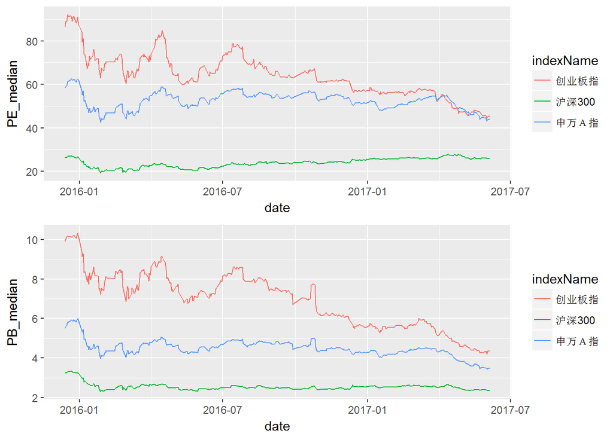

### (a2)动态市盈率、市净率百分位

核心指数近18个月的动态市盈率百分位及动态市净率百分位走势如下图所示：

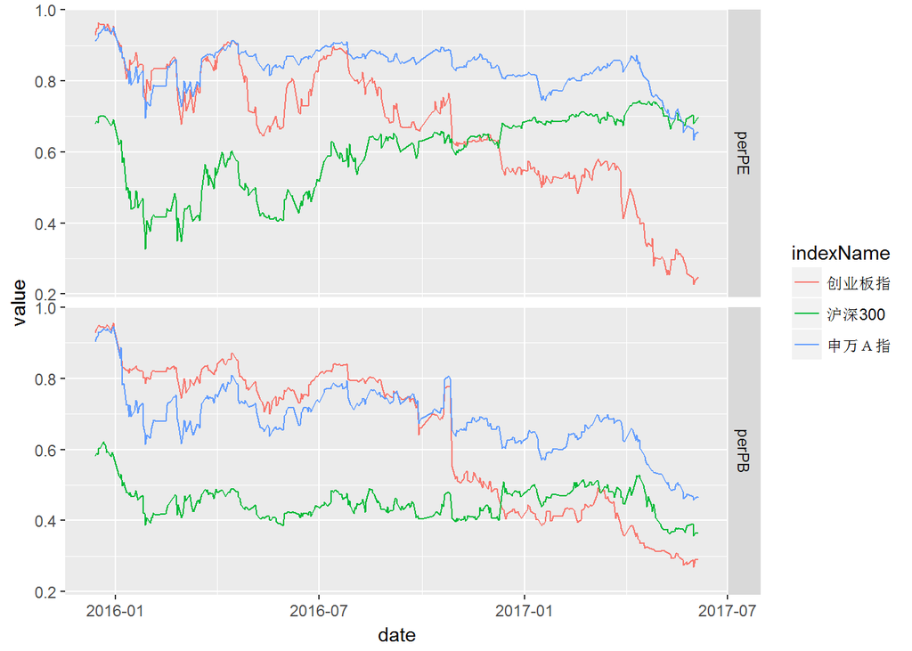

### (a3)指数估值概览

纳入观察的指数最新的估值情况如下表，根据市盈率和市净率分位数均值降序排列。

| 指数代码 | 指数简称 | 日期 | 动态市盈率 | 市盈率百分位 | 动态市净率 | 市净率百分位 |
| --- | --- | --- | --- | --- | --- | --- |
| EI801003 | 申万Ａ指 | 2017-06-05 | 44.1 | 66% | 3.5 | 47% |
| EI399330 | 深证100 | 2017-06-05 | 31.1 | 63% | 3.4 | 43% |
| EI000300 | 沪深300 | 2017-06-05 | 26.1 | 70% | 2.4 | 36% |
| EI399959 | 军工指数 | 2017-06-05 | 80.4 | 54% | 3.8 | 44% |
| EI399005 | 中小板指P | 2017-06-05 | 39.3 | 57% | 4.1 | 30% |
| EI000979 | 大宗商品 | 2017-06-05 | 29.8 | 52% | 2.4 | 35% |
| EI000819 | 有色金属 | 2017-06-05 | 47.3 | 63% | 2.9 | 22% |
| EI000016 | 上证50 | 2017-06-05 | 18.7 | 67% | 1.6 | 10% |
| EI000934 | 中证金融 | 2017-06-05 | 19.3 | 65% | 1.7 | 10% |
| EI000905 | 中证500 | 2017-06-05 | 34.1 | 41% | 2.7 | 25% |
| EI000998 | 中证TMT | 2017-06-05 | 40.4 | 34% | 3.6 | 29% |
| EI399006 | 创业板指 | 2017-06-05 | 45.5 | 25% | 4.4 | 29% |
| EI000922 | 中证红利 | 2017-06-05 | 15.3 | 22% | 1.6 | 13% |
| EI000932 | 中证消费 | 2017-06-05 | 29.1 | 26% | 3.4 | 7% |
| EI000827 | 中证环保 | 2017-06-05 | 33.4 | 17% | 2.7 | 15% |
| EI000933 | 中证医药 | 2017-06-05 | 31.3 | 14% | 3.5 | 1% |

### (a4)另类估值

我国10年期国债收益率、金银比价、金油比价，2000年以来的历史百分位如下图所示：

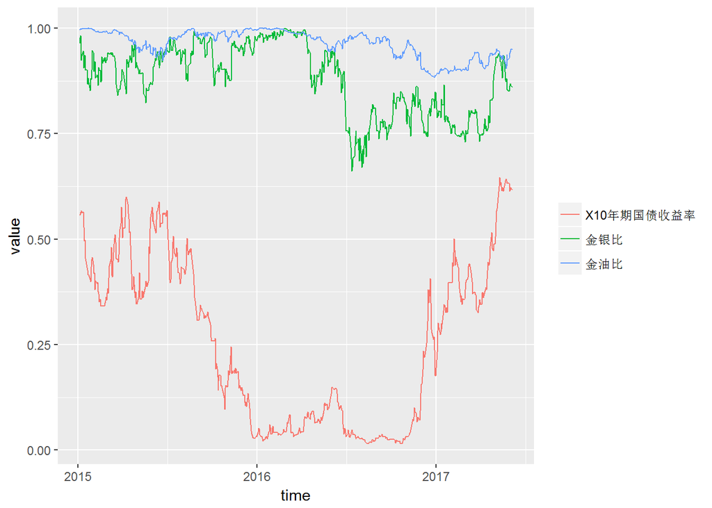

## B、基差及市场情绪

### (b1)基差走势

三大股指期货合约基差走势如下图，其中当月合约和次月合约年化基差百分比波动较大，仅展示合约基差百分比，当季合约和次季合约展示基差年化百分比：

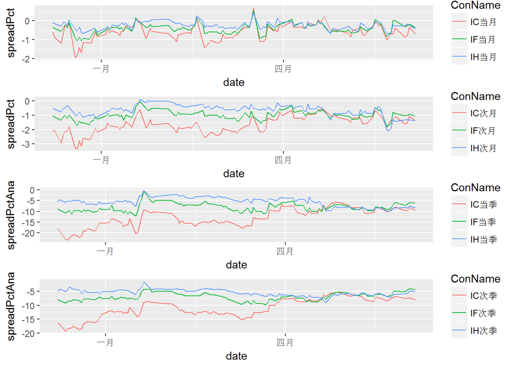

### (b2)基差概况

三大股指期货连续合约基差概况如下表，近月合约临近到期日，年化基差百分比数据波动较大：

| 日期 | 合约代码 | 合约收盘价 | 指数收盘价 | 基差 | 基差百分比 | 年化基差百分比 |
| --- | --- | --- | --- | --- | --- | --- |
| 2017-06-05 | IC1706 | 5775.0 | 5815.8 | -40.8 | -0.7% | -26.1% |
| 2017-06-05 | IC1707 | 5734.4 | 5815.8 | -81.4 | -1.4% | -11.7% |
| 2017-06-05 | IC1709 | 5665.8 | 5815.8 | -150.0 | -2.6% | -9.5% |
| 2017-06-05 | IC1712 | 5575.4 | 5815.8 | -240.4 | -4.1% | -8.0% |
| 2017-06-05 | IF1706 | 3456.6 | 3468.8 | -12.2 | -0.4% | -12.3% |
| 2017-06-05 | IF1707 | 3432.0 | 3468.8 | -36.8 | -1.1% | -8.7% |
| 2017-06-05 | IF1709 | 3409.2 | 3468.8 | -59.6 | -1.7% | -6.3% |
| 2017-06-05 | IF1712 | 3390.0 | 3468.8 | -78.8 | -2.3% | -4.3% |
| 2017-06-05 | IH1706 | 2440.2 | 2450.3 | -10.1 | -0.4% | -14.7% |
| 2017-06-05 | IH1707 | 2416.8 | 2450.3 | -33.5 | -1.4% | -11.4% |
| 2017-06-05 | IH1709 | 2395.0 | 2450.3 | -55.3 | -2.3% | -8.3% |
| 2017-06-05 | IH1712 | 2383.8 | 2450.3 | -66.5 | -2.7% | -5.2% |

### (b3)市场情绪(provided by han.qian)

市场情绪记录近60天每天自然涨跌停(剔除一字板)、创60日新高新低、多头排列空头排列(均线组合5,30,60,120)的股票数。

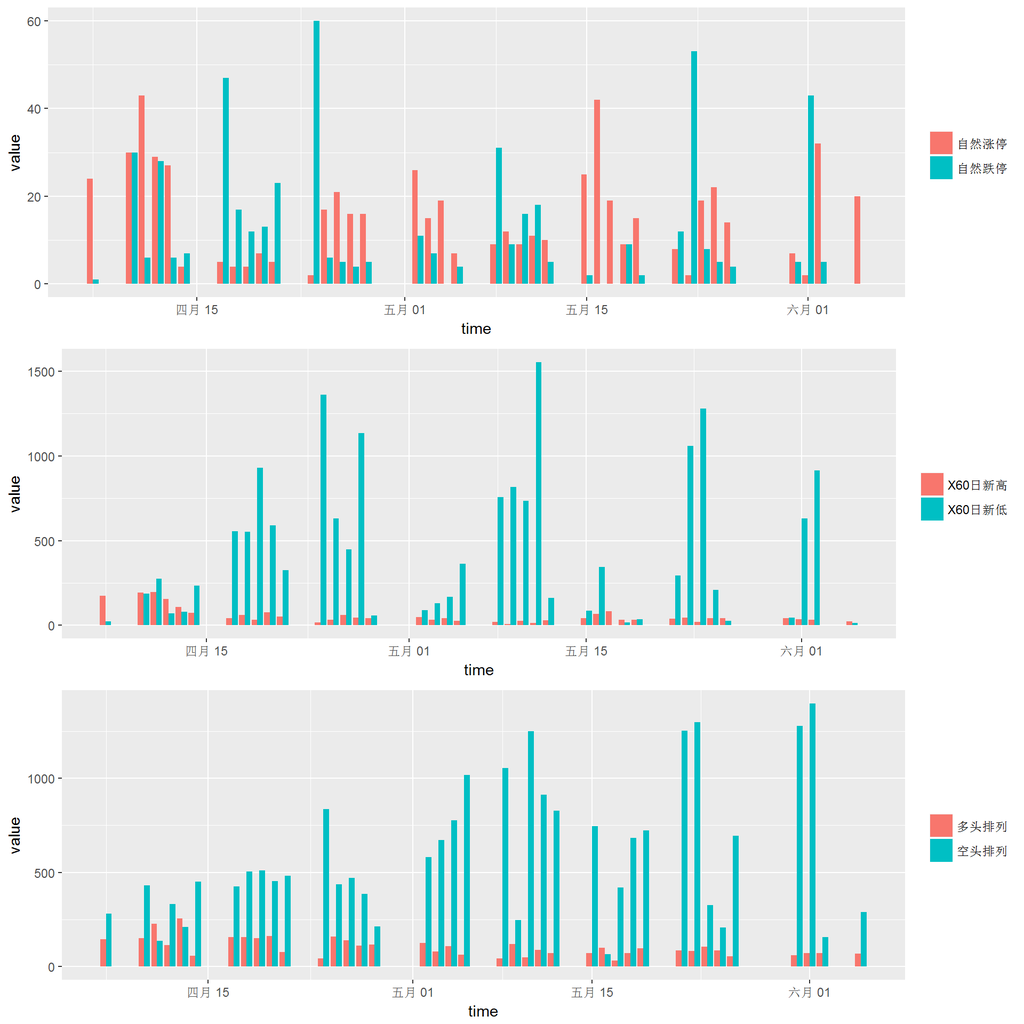

## C、套利和事件

### (c1)复牌股票套利

近两天复牌股票套利情况如下表：

[1] “No Arbitrage!”

### (c2)定增基金(provided by han.qian)

定增基金数据如下表，明细数据参见钱瀚的模板。

| 代码 | 名称 | 到期日期 | 最新净值 | 昨日收盘价 | 折溢价率 | 整体隐含折价率 | 大盘下跌0.1净值变化 |
| --- | --- | --- | --- | --- | --- | --- | --- |
| 168101.OF | 九泰锐智 | 20200814 | 1.09 | 0.88 | -19.7% | 3.5% | -10.1% |
| 168102.OF | 九泰锐富 | 20210204 | 0.95 | 0.74 | -22.8% | 2.0% | -5.6% |
| 501015.OF | 财通升级 | 20170908 | 0.95 | 0.88 | -7.8% | 0.7% | -9.2% |
| 160518.OF | 博时睿远 | 20171016 | 0.93 | 0.85 | -8.7% | 0.6% | -6.8% |

定增基金近期的净值走势如下图：

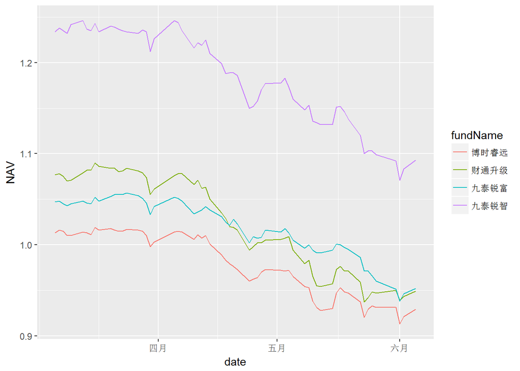

定增基金近期的折溢价率百分比走势如下图：

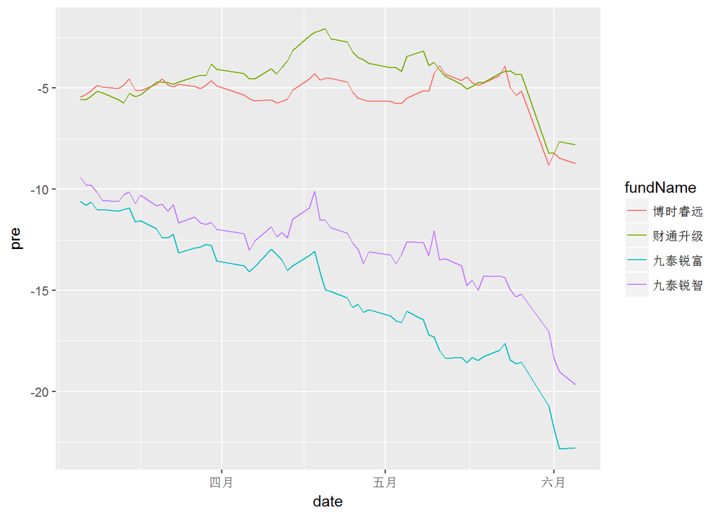

### (c3)解禁

解禁分成两个部分，定增解禁和IPO解禁，涨跌幅记录是过去十个交易日的股票涨跌幅和对应行业指数涨跌幅。伴随着去年下半年IPO逐步正常化，今后IPO解禁给市场造成的抛压会持续存在，所以纳入观察。近期定增解禁的股票情况如下表。

| 股票代码 | 股票简称 | 解禁日 | 解禁数量 | 解禁百分比 | 区间涨跌幅 | 所属行业指数 | 行业指数涨跌幅 |
| --- | --- | --- | --- | --- | --- | --- | --- |
| EQ600900 | 长江电力 | 2017-06-07 | 17.60 | 18% | 3.4% | 申万公用事业 | -2.2% |
| EQ002373 | 千方科技 | 2017-06-07 | 2.90 | 52% | -17.1% | 申万计算机 | -3.3% |
| EQ601567 | 三星医疗 | 2017-06-07 | 2.20 | 22% | 0.8% | 申万电气设备 | -3.8% |
| EQ000631 | 顺发恒业 | 2017-06-07 | 2.66 | 12% | -1.2% | 申万房地产 | 1.3% |
| EQ300008 | 天海防务 | 2017-06-07 | 0.64 | 12% | -19.4% | 申万国防军工 | -4.5% |
| EQ300209 | 天泽信息 | 2017-06-07 | 0.47 | 22% | 0.0% | 申万计算机 | -3.3% |
| EQ002259 | 升达林业 | 2017-06-08 | 1.09 | 18% | -2.9% | 申万轻工制造 | -4.2% |
| EQ601233 | 桐昆股份 | 2017-06-08 | 2.42 | 25% | -7.6% | 申万化工 | -4.1% |
| EQ002247 | 帝龙文化 | 2017-06-08 | 0.60 | 13% | -4.8% | 申万轻工制造 | -4.2% |
| EQ600747 | *ST大控 | 2017-06-12 | 4.00 | 38% | -8.6% | 申万非银金融 | 4.2% |
| EQ300148 | 天舟文化 | 2017-06-12 | 0.71 | 14% | 0.0% | 申万传媒 | -3.1% |
| EQ000571 | 新大洲A | 2017-06-13 | 0.78 | 11% | 0.0% | 申万采掘 | 0.1% |
| EQ002425 | 凯撒文化 | 2017-06-13 | 0.73 | 12% | -1.4% | 申万纺织服装 | -3.9% |
| EQ002094 | 青岛金王 | 2017-06-15 | 0.36 | 11% | -7.2% | 申万轻工制造 | -4.2% |
| EQ000547 | 航天发展 | 2017-06-16 | 1.14 | 13% | -3.9% | 申万通信 | -3.4% |
| EQ300222 | 科大智能 | 2017-06-16 | 1.56 | 55% | -21.6% | 申万电气设备 | -3.8% |
| EQ002200 | 云投生态 | 2017-06-19 | 0.33 | 31% | -19.6% | 申万建筑装饰 | -2.0% |
| EQ603118 | 共进股份 | 2017-06-19 | 1.02 | 38% | -6.1% | 申万通信 | -3.4% |
| EQ002005 | 德豪润达 | 2017-06-19 | 2.30 | 20% | -7.2% | 申万电子 | -4.1% |
| EQ600807 | 天业股份 | 2017-06-20 | 2.11 | 32% | -3.0% | 申万房地产 | 1.3% |
| EQ000530 | 大冷股份 | 2017-06-20 | 0.82 | 23% | -1.3% | 申万机械设备 | -4.5% |
| EQ000885 | 同力水泥 | 2017-06-20 | 0.48 | 11% | 0.0% | 申万建筑材料 | -5.0% |
| EQ002021 | 中捷资源 | 2017-06-20 | 1.20 | 21% | -3.7% | 申万机械设备 | -4.5% |
| EQ002277 | 友阿股份 | 2017-06-20 | 2.84 | 25% | -2.0% | 申万商业贸易 | -2.0% |
| EQ300031 | 宝通科技 | 2017-06-20 | 0.29 | 13% | -2.1% | 申万化工 | -4.1% |

近期IPO解禁的股票情况如下表。

| 股票代码 | 股票简称 | 解禁日 | 解禁数量 | 解禁百分比 | 区间涨跌幅 | 所属行业指数 | 行业指数涨跌幅 | 上市日 |
| --- | --- | --- | --- | --- | --- | --- | --- | --- |
| EQ002294 | 信立泰 | 2017-05-26 | 5.56 | 114% | 2.5% | 申万医药生物 | -1.5% | 2009-09-10 |
| EQ300512 | 中亚股份 | 2017-05-26 | 0.10 | 15% | -8.0% | 申万机械设备 | -4.5% | 2016-05-26 |
| EQ002798 | 帝王洁具 | 2017-05-26 | 0.10 | 48% | -3.6% | 申万轻工制造 | -4.2% | 2016-05-25 |
| EQ300468 | 四方精创 | 2017-05-31 | 0.09 | 16% | -6.2% | 申万计算机 | -3.3% | 2015-05-27 |
| EQ601198 | 东兴证券 | 2017-05-31 | 1.00 | 11% | 2.9% | 申万非银金融 | 4.2% | 2015-02-26 |
| EQ002800 | 天顺股份 | 2017-05-31 | 0.16 | 87% | -6.0% | 申万交通运输 | -1.4% | 2016-05-30 |
| EQ300513 | 恒泰实达 | 2017-06-02 | 0.18 | 94% | -13.0% | 申万计算机 | -3.3% | 2016-05-30 |
| EQ300516 | 久之洋 | 2017-06-02 | 0.05 | 17% | -8.7% | 申万电子 | -4.1% | 2016-06-02 |
| EQ603737 | 三棵树 | 2017-06-05 | 0.05 | 21% | 1.8% | 申万化工 | -4.1% | 2016-06-03 |
| EQ300370 | 安控科技 | 2017-06-06 | 0.56 | 11% | -10.4% | 申万电气设备 | -3.8% | 2014-01-23 |
| EQ002799 | 环球印务 | 2017-06-08 | 0.26 | 105% | -18.7% | 申万轻工制造 | -4.2% | 2016-06-08 |
| EQ300515 | 三德科技 | 2017-06-08 | 0.19 | 77% | -20.0% | 申万机械设备 | -4.5% | 2016-06-08 |
| EQ601611 | 中国核建 | 2017-06-12 | 4.37 | 83% | -9.4% | 申万建筑装饰 | -2.0% | 2016-06-06 |
| EQ300475 | 聚隆科技 | 2017-06-12 | 0.11 | 18% | -23.7% | 申万家用电器 | 1.8% | 2015-06-10 |
| EQ601127 | 小康股份 | 2017-06-15 | 0.38 | 26% | -8.7% | 申万汽车 | -1.9% | 2016-06-15 |

### (c4)中小板业绩预增预测(provided by han.qian)

中小板规定正式财务报告发布的同时需要发布新一期的业绩预报，比如年报中会包含一季报预告的情况。我们假设公司的盈利状况有动量效应，年报预增的公司一季度也会预增，在正式财务报告发布前20个交易日开始埋伏，然后等正式报告发布日卖出。具体研究参见钱瀚前期的研究。需要注意的是这里的收益率仅做展示，仅仅是每日全部入选股票的平均收益率，并没有做成一个事件组合。

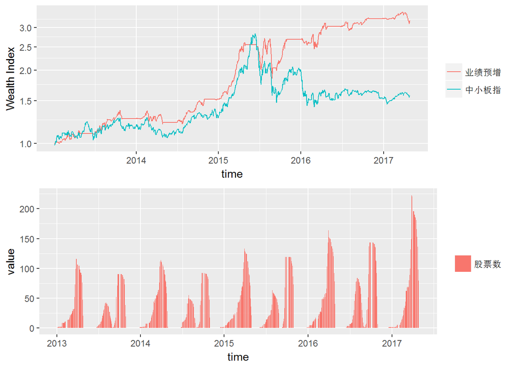

历年收益统计如下表所示。

|  | 业绩预增 | 中小板指 |
| --- | --- | --- |
| 2013-01-04 ~ 2013-12-31 | 26.4% | 17.5% |
| 2014-01-02 ~ 2014-12-31 | 20.4% | 9.7% |
| 2015-01-05 ~ 2015-12-31 | 76.6% | 53.7% |
| 2016-01-04 ~ 2016-12-30 | 21.9% | -22.9% |
| 2017-01-03 ~ 2017-04-28 | -1.8% | 2.6% |
| Cumulative Return | 221.9% | 56.7% |
| Annualized Return | 31.1% | 11.0% |